# Swire_Capstone_Modeling_Group_4

1. Introduction
2. Installing required packages
3. Loading Datasets and Data Description
   - 3.1.Fact Market Demand Data
   - 3.2.Customer Demographics Data
   - 3.3.Zip Code Data
   - 3.4 Missing Data
4. Modeling
   - 4.1.Linear Regression
     - 4.1.1 Encoding
     - 4.1.2 Ridge
     - 4.1.3 Random Forest
     - 4.1.4 XG Boost
   - 4.2.Autoregression (AR) Model
   - 4.3.ARIMA Model
     - 4.3.1 Question 1 with ARIMA
     - 4.3.2 Question 3 with ARIMA
   - 4.4.Prophet Model
     - 4.4.1 Holiday Data
     - 4.4.2 Question 1
     - 4.4.3 Question 2
     - 4.4.4 Question 3
5. Model Findings
6. Conclusion
7. Group Member Contribution

# 1. Introduction

Swire Coca-Cola is continually introducing innovative products into the market. Innovation diversifies product offerings, meeting evolving consumer trends. This strategy, marked by unique products and premium pricing, expands market reach and attracts new customers. It responds to technology changes and regulations, ensuring cost efficiency and compliance. Additionally, it rejuvenates sales and marketing. In essence, product innovation is essential for staying relevant, driving revenue, and sustaining long-term growth in a dynamic market.

So, Swire Coca-Cola wants to optimize its production planning and inventory management for these novel beverages. The challenge for Swire is to forecast the demand for these new products accurately to ensure optimal production quantities, prevent out-of-stock and overproduction, minimize costs, and maximize customer satisfaction. The Business problem is to accurately predict the weekly demand of the innovation products. The focus of our project will be on optimal production planning, cost minimization, and market location and date prediction.

The Analytical Problem is to forecast the details expected by the Swire for the 7 innovation products that are planned to be launched in the near future. The basic details of each of the new innovation products are provided so that it can be compared against the historical data and can be used to forecast the sales of the innovation products as close as possible to the real time sales.

The key factors for the Items are the Caloric Segment, Market Category, Manufacturer, Brand, Package Type and Flavor which will be used as the independent variables from the Previous years data to create a Forecast for the new innovation Products. So, the Target variable is the Dollar Sales/unit sales for the innovation products.

In this notebook we will create the forecasting models to predict the demand for the new innovation products that the Swire team is expecting to launch in the next year. The scope includes creating the end-to-end development of the forecasting models to find the pattern of the sales for the products and also to discover some insights for improving the sales of innovation products. It aims to provide Swire with the insights and tools necessary to maintain its Sales while making data-driven decisions that can contribute to the success of the innovation Products.

# 2. Installing required packages

```python
import warnings
warnings.filterwarnings("ignore")
```

```python
!pip install google.cloud.bigquery
```

```python
import os
import numpy as np
import pandas as pd
import math
import itertools
from scipy import stats
import time


#matplotlib libraries
import matplotlib.pyplot as plt
import matplotlib.patches as mp
import matplotlib.image as mpimg
import matplotlib.cm as cm
import matplotlib.colors
import seaborn as sns

#date libraries
from dateutil import parser
from datetime import datetime, timedelta, date
import holidays

#prophet library
from prophet import Prophet
from prophet.diagnostics import performance_metrics
from prophet.plot import plot_cross_validation_metric
from prophet.diagnostics import cross_validation

#xgboost
from xgboost import XGBRegressor

#sklearn
from sklearn.metrics import mean_absolute_error, mean_squared_error, r2_score
from sklearn.model_selection import train_test_split
from sklearn.metrics import mean_squared_error, r2_score
from sklearn.preprocessing import LabelEncoder
from sklearn.ensemble import RandomForestRegressor
from sklearn.linear_model import LinearRegression, Ridge
from sklearn.model_selection import cross_val_score
from sklearn.model_selection import GridSearchCV
from sklearn.model_selection import RandomizedSearchCV
from sklearn.model_selection import TimeSeriesSplit
from sklearn.preprocessing import StandardScaler
from sklearn.cluster import KMeans

from statsmodels.tsa.arima.model import ARIMA
from sklearn.model_selection import TimeSeriesSplit
from statsmodels.tsa.holtwinters import ExponentialSmoothing
from itertools import combinations
from statsmodels.tsa.ar_model import AutoReg
from itertools import combinations
from scipy.optimize import fminbound
```

```python
#pandas options
pd.set_option('display.float_format', lambda x: '%.2f' % x)
pd.set_option('display.max_columns', None)
pd.set_option('display.max_rows', None)

#matplotlib setting defaults
sns.set(
        rc={
 "axes.axisbelow": False,
 "axes.edgecolor": "lightgrey",
 "axes.facecolor": "None",
 "axes.grid": False,
 "axes.labelcolor": "dimgrey",
 "axes.spines.right": False,
 "axes.spines.top": False,
 "figure.facecolor": "white",
 "lines.solid_capstyle": "round",
 "patch.edgecolor": "w",
 "patch.force_edgecolor": True,
 "text.color": "dimgrey",
 "xtick.bottom": False,
 "xtick.color": "dimgrey",
 "xtick.direction": "out",
 "xtick.top": False,
 "ytick.color": "dimgrey",
 "ytick.direction": "out",
 "ytick.left": False,
 "ytick.right": False})
```

```python
from google.cloud import bigquery
from google.oauth2 import service_account
import pandas as pd

from google.colab import auth

# Authenticate user
auth.authenticate_user()
```

```python
# Create a BigQuery client
client = bigquery.Client(project='is-6813-spring-24')
```

# 3. Loading Datasets and Data Description

## 3.1 Fact Market Demand Data

The main data file is the fact_market_demand data since that seems to hold the most value for answering the business problem. There are 10 fields and 24,461,424 rows. The columns are data, unit_sales, caloric_segment, category, manufacturer, brand, package, item, market_key and dollar_sales.

The date range is nearly three full years, spanning December 2020 to October 2023. The caloric segment is a categorical column with values Regular and Diet/light.

```python
# Get Fact_Market_Demand Data from BigQuery

fact_demand_query = """
select * from `swire.fact_market_demand`
"""
# Execute the query
fact_demand_query_job = client.query(fact_demand_query)

# Get the results as a Pandas DataFrame
Fact_Demand_data = fact_demand_query_job.to_dataframe()

# Display Fact_market_demand data
Fact_Demand_data.head()
```

|  | DATE | MARKET_KEY | CALORIC_SEGMENT | CATEGORY | UNIT_SALES | DOLLAR_SALES | MANUFACTURER | BRAND | PACKAGE | ITEM |
| --- | --- | --- | --- | --- | --- | --- | --- | --- | --- | --- |
| 0 | 2020-12-26 | 530 | DIET/LIGHT | ENERGY | 64.00 | 131.12 | PONYS | MYTHICAL BEVERAGE DRAGON TEA | 16SMALL MULTI CUP | MYTHICAL BEVERAGE LIZARD DRINK DRINK FLAVOR... |
| 1 | 2023-04-29 | 849 | DIET/LIGHT | SSD | 30.00 | 194.93 | JOLLYS | HILL MOISTURE ZERO SUGAR SPARK | 12SMALL 12ONE CUP | RAINING ZERO SUGAR SPARK GENTLE DRINK RAZZ AD... |
| 2 | 2021-03-27 | 966 | DIET/LIGHT | SSD | 18.00 | 83.16 | COCOS | DIET BUBBLE JOY ADVANTAGEOUS CF | 12SMALL 8ONE SHADYES JUG | DIET BUBBLE JOY ADVANTAGEOUS CAFFEINE FREE GEN... |
| 3 | 2022-12-17 | 303 | DIET/LIGHT | SSD | 231.00 | 1148.06 | COCOS | DIET BUBBLE JOY ADVANTAGEOUS CF | 12SMALL 12ONE CUP | DIET BUBBLE JOY ADVANTAGEOUS CAFFEINE FREE GEN... |
| 4 | 2022-07-23 | 464 | REGULAR | SSD | 132.00 | 797.68 | COCOS | MEXICAN BUBBLE JOY ADVANTAGEOUS | 12SMALL 4ONE PLASTICS JUG | KOOL! GENTLE DRINK COLA JUG 12 LIQUID SMALL X4 |

```python
# Get a summary of the dataset
print(Fact_Demand_data.describe())
```

```
       MARKET_KEY  UNIT_SALES  DOLLAR_SALES
count 24461424.00 24461424.00   24461424.00
mean       593.14      174.37        591.14
std        605.88      857.81       3040.54
min          1.00        0.04          0.01
25%        260.00       11.00         36.59
50%        547.00       40.00        135.05
75%        845.00      126.00        427.14
max       6802.00    96776.00     492591.07
```

```python
print(Fact_Demand_data.info())
```

```
<class 'pandas.core.frame.DataFrame'>
RangeIndex: 24461424 entries, 0 to 24461423
Data columns (total 10 columns):
 #   Column           Dtype
---  ------           -----
 0   DATE             dbdate
 1   MARKET_KEY       Int64
 2   CALORIC_SEGMENT  object
 3   CATEGORY         object
 4   UNIT_SALES       float64
 5   DOLLAR_SALES     float64
 6   MANUFACTURER     object
 7   BRAND            object
 8   PACKAGE          object
 9   ITEM             object
dtypes: Int64(1), dbdate(1), float64(2), object(6)
memory usage: 1.8+ GB
None
```

```python
# Check for missing values
print(Fact_Demand_data.isnull().sum())
```

```
DATE                   0
MARKET_KEY             0
CALORIC_SEGMENT    59725
CATEGORY               0
UNIT_SALES             0
DOLLAR_SALES           0
MANUFACTURER           0
BRAND                  0
PACKAGE                0
ITEM                   0
dtype: int64
```

In the Fact Demand data we can see that there are 59725 missing data in the CALORIC_SEGMENT Column. Before replacing that let us look at how the CALORIC_SEGMENT data is disctributed by using the count SQL query from Big Query as the processing time will be more if done from dataframe object.

```python
# Get Caloric Segment data from Fact_Market_Demand Data from BigQuery

CS_query = """
select CALORIC_SEGMENT,
count(*) as Count_caloric_segment
from `swire.fact_market_demand`
group by CALORIC_SEGMENT;
"""
# Execute the query
CS_job = client.query(CS_query)

# Get the results as a Pandas DataFrame
CS_data = CS_job.to_dataframe()

CS_data.head()
```

|  | CALORIC_SEGMENT | Count_caloric_segment |
| --- | --- | --- |
| 0 | REGULAR | 12231585 |
| 1 | DIET/LIGHT | 12170114 |
| 2 | None | 59725 |

## 3.2 Customer Demographics Data

The customer_demographics data provides information on the demographics with respect to zip codes like Age, Gender with age, Education, Income range, Marraige status, Race and Household information.

All of these demographic information is combined and can be divided by filtering the 'Segment' field for each type like Household income, education, etc.

```python
# Get consumer_demographics Data from BigQuery

demograph_query = """
select * from `swire.consumer_demographics`
"""
# Execute the query
demograph_query_job = client.query(demograph_query)

# Get the results as a Pandas DataFrame
Demographics_data = demograph_query_job.to_dataframe()

# Display Fact_market_demand data
Demographics_data.head()
```

|  | Geography_Name | Zip | City | State | Segment | Criteria | Count | Criteria_Unit |
| --- | --- | --- | --- | --- | --- | --- | --- | --- |
| 0 | 57064 Tea, SD | 57064 | Tea | SD | Household Income | Income Under $10,000 | 36 | HHs |
| 1 | 57064 Tea, SD | 57064 | Tea | SD | Household Income | Income $10,000 - $19,999 | 86 | HHs |
| 2 | 57064 Tea, SD | 57064 | Tea | SD | Household Income | Income $20,000 - $29,999 | 87 | HHs |
| 3 | 57064 Tea, SD | 57064 | Tea | SD | Household Income | Income $30,000 - $39,999 | 137 | HHs |
| 4 | 57064 Tea, SD | 57064 | Tea | SD | Household Income | Income $40,000 - $49,999 | 85 | HHs |

```python
# Check for missing value in Demographics data
print(Demographics_data.isnull().sum())
```

```
Geography_Name    0
Zip               0
City              0
State             0
Segment           0
Criteria          0
Count             0
Criteria_Unit     0
dtype: int64
```

## 3.3 Zip Code Data

This zip to market unit mapping data contains only Zip code to the market key information. This information can be used to connect the Demographics data to the Fact_Market_Demand data and also to know which Market key belongs to which region in country based on the Zip codes.

```python
# Get zip_to_market_unit_mapping Data from BigQuery

zip_market_query = """
select * from `swire.zip_to_market_unit_mapping`
"""
# Execute the query
zip_market_query_job = client.query(zip_market_query)

# Get the results as a Pandas DataFrame
zip_market_data = zip_market_query_job.to_dataframe()

# Display Fact_market_demand data
zip_market_data.head()
```

|  | ZIP_CODE | MARKET_KEY |
| --- | --- | --- |
| 0 | 83462 | 1 |
| 1 | 83463 | 1 |
| 2 | 83466 | 1 |
| 3 | 83467 | 1 |
| 4 | 83525 | 1 |

```python
# Check for missing values in Zip Market data
print(zip_market_data.isnull().sum())
```

```
ZIP_CODE      0
MARKET_KEY    0
dtype: int64
```

## 3.5. Feature Engineering

Before starting the Data Exploration, we want to include few of the new columns derived from the original data and added into the data.

Let us join the Demographics data with the Zip_to_market Data to get the States for each of the Market keys. Since some Market_keys contain zipcodes of multiple states we divide states by '/' and keep it in one column named 'States'.

Then we will attach the States column to the main fact_demand_data so that we get the states information for each of sales data.

We will get all this from Bigquery to reduce the run time.

```python
#Google Big Query
ZMS_query = """
SELECT DISTINCT c.*, d.States
FROM `is-6813-spring-24.swire.fact_market_demand` as c
inner join
( SELECT a.MARKET_KEY, STRING_AGG(DISTINCT b.State, '/') AS States
FROM `is-6813-spring-24.swire.zip_to_market_unit_mapping` AS a
INNER JOIN `is-6813-spring-24.swire.consumer_demographics` AS b
ON b.Zip = a.ZIP_CODE
GROUP BY a.MARKET_KEY )
as d
ON c.MARKET_KEY = d.MARKET_KEY
ORDER BY c.DATE, c. MARKET_KEY, c.ITEM
"""
# Execute the query
ZMS_job = client.query(ZMS_query)

# Get the results as a Pandas DataFrame
fact_demand_state_data = ZMS_job.to_dataframe()

fact_demand_state_data.head()
```

|  | DATE | MARKET_KEY | CALORIC_SEGMENT | CATEGORY | UNIT_SALES | DOLLAR_SALES | MANUFACTURER | BRAND | PACKAGE | ITEM | States |
| --- | --- | --- | --- | --- | --- | --- | --- | --- | --- | --- | --- |
| 0 | 2020-12-05 | 1 | REGULAR | ENERGY | 3.00 | 23.88 | JORDYS | LIQUORICE | ALL OTHER ONES | AAE LIQUORICE XTREME DIETARY HEALTH SUPPLEMENT... | ID |
| 1 | 2020-12-05 | 1 | REGULAR | ENERGY | 1.00 | 7.96 | JORDYS | LIQUORICE | ALL OTHER ONES | AAE LIQUORICE XTREME REVITALIZING BOOST LIQUID... | ID |
| 2 | 2020-12-05 | 1 | DIET/LIGHT | ENERGY | 9.00 | 23.78 | JORDYS | LIQUORICE | ALL OTHER ONES | AAE LIQUORICE XTREME REVITALIZING BOOST LIQUID... | ID |
| 3 | 2020-12-05 | 1 | DIET/LIGHT | SPARKLING WATER | 114.00 | 375.09 | JOLLYS | BUBBLE JOY | 12SMALL 8ONE CUP | BUBBLE JOY SPARKLING WATER CASAVA BUBBLE JOY ... | ID |
| 4 | 2020-12-05 | 1 | DIET/LIGHT | SPARKLING WATER | 178.00 | 588.82 | JOLLYS | BUBBLE JOY | 12SMALL 8ONE CUP | BUBBLE JOY SPARKLING WATER DURIAN BUBBLE JOY ... | ID |

```python
# Convert DATE column to datetime
fact_demand_state_data['DATE'] = pd.to_datetime(fact_demand_state_data['DATE'])
```

```python
fact_demand_state_data.head()
```

|  | DATE | MARKET_KEY | CALORIC_SEGMENT | CATEGORY | UNIT_SALES | DOLLAR_SALES | MANUFACTURER | BRAND | PACKAGE | ITEM | States |
| --- | --- | --- | --- | --- | --- | --- | --- | --- | --- | --- | --- |
| 0 | 2020-12-05 | 1 | REGULAR | ENERGY | 3.00 | 23.88 | JORDYS | LIQUORICE | ALL OTHER ONES | AAE LIQUORICE XTREME DIETARY HEALTH SUPPLEMENT... | ID |
| 1 | 2020-12-05 | 1 | REGULAR | ENERGY | 1.00 | 7.96 | JORDYS | LIQUORICE | ALL OTHER ONES | AAE LIQUORICE XTREME REVITALIZING BOOST LIQUID... | ID |
| 2 | 2020-12-05 | 1 | DIET/LIGHT | ENERGY | 9.00 | 23.78 | JORDYS | LIQUORICE | ALL OTHER ONES | AAE LIQUORICE XTREME REVITALIZING BOOST LIQUID... | ID |
| 3 | 2020-12-05 | 1 | DIET/LIGHT | SPARKLING WATER | 114.00 | 375.09 | JOLLYS | BUBBLE JOY | 12SMALL 8ONE CUP | BUBBLE JOY SPARKLING WATER CASAVA BUBBLE JOY ... | ID |
| 4 | 2020-12-05 | 1 | DIET/LIGHT | SPARKLING WATER | 178.00 | 588.82 | JOLLYS | BUBBLE JOY | 12SMALL 8ONE CUP | BUBBLE JOY SPARKLING WATER DURIAN BUBBLE JOY ... | ID |

## 3.4. Missing Data

Since both the Regular and Diet/light categories are equal we are unable to categorize the null value to any of the categories without disturbing the other data present. So, We can just replace that Null values with the string of 'Unknown', so that the data is not impacted.

```python
# Handling missing values

fact_demand_state_data['CALORIC_SEGMENT'].fillna('Unknown', inplace=True)
```

```python
# checking for missing data again

print(fact_demand_state_data.isnull().sum())
```

```
DATE               0
MARKET_KEY         0
CALORIC_SEGMENT    0
CATEGORY           0
UNIT_SALES         0
DOLLAR_SALES       0
MANUFACTURER       0
BRAND              0
PACKAGE            0
ITEM               0
States             0
dtype: int64
```

```python
# Handling missing values

Fact_Demand_data['CALORIC_SEGMENT'].fillna('Unknown', inplace=True)
```

```python
# checking for missing data again

print(Fact_Demand_data.isnull().sum())
```

```
DATE               0
MARKET_KEY         0
CALORIC_SEGMENT    0
CATEGORY           0
UNIT_SALES         0
DOLLAR_SALES       0
MANUFACTURER       0
BRAND              0
PACKAGE            0
ITEM               0
dtype: int64
```

# 4. Modeling

First defining the required functions like missing_data and MAPE which will help us further in the Modeling Process and for finding the best model for Forecasting.

```python
def missing_data(input_data):
    '''
    This function returns dataframe with information about the percentage of nulls in each column and the column data type.

    input: pandas df
    output: pandas df

    '''

    total = input_data.isnull().sum()
    percent = (input_data.isnull().sum()/input_data.isnull().count()*100)
    table = pd.concat([total, percent], axis = 1, keys = ['Total', 'Percent'])
    types = []
    for col in input_data.columns:
        dtype = str(input_data[col].dtype)
        types.append(dtype)
    table["Types"] = types
    return(pd.DataFrame(table))

def mape(actual, pred):
    '''
    Mean Absolute Percentage Error (MAPE) Function

    input: list/series for actual values and predicted values
    output: mape value
    '''
    actual, pred = np.array(actual), np.array(pred)
    return np.mean(np.abs((actual - pred) / actual)) * 100
```

## 4.1 Linear Regression

## 4.1.1 Encoding

First Starting the modeling process by encoding the Categorical variables for the Linear Regression and XGBoost and Random Forest Modeling Techniques

```python
from sklearn.impute import SimpleImputer
from sklearn.preprocessing import LabelEncoder

data = Fact_Demand_data.copy()

# Get numeric columns
numeric_cols = data.select_dtypes(include=['int', 'float']).columns.tolist()

# Get categorical columns
categorical_cols = data.select_dtypes(include=['object']).columns.tolist()


# Fill missing values for numerical columns
for col in numeric_cols:
    data[col].fillna(data[col].median(), inplace=True)

# Encode categorical variables using LabelEncoder
label_encoders = {}
for col in categorical_cols:
    label_encoders[col] = LabelEncoder()
    data[col] = label_encoders[col].fit_transform(data[col].astype(str))

# Split data into features and target
X = data[categorical_cols + numeric_cols]  # Adjust based on your specific columns
y = data['UNIT_SALES']
```

Now let's split the data into training and testing sets for the Linear Regression model and fit the data using the Linear Regression model.

```python
X_train, X_test, y_train, y_test = train_test_split(X, y, test_size=0.3, random_state=47, stratify=data['CATEGORY'])

# Considering training on a subset for efficiency
train_sample = X_train.sample(frac=0.1, random_state=42)
target_sample = y_train.loc[train_sample.index]

model = LinearRegression()
model.fit(train_sample, target_sample)
```

```
LinearRegression()
```

```python
# Making predictions on the test set sample
test_sample = X_test.sample(frac=0.1, random_state=47)
test_target_sample = y_test.loc[test_sample.index]

y_pred_sample = model.predict(test_sample)

# Evaluate
mse_sample = mean_squared_error(test_target_sample, y_pred_sample)
r2_sample = r2_score(test_target_sample, y_pred_sample)

print(f"Sample Mean Squared Error: {mse_sample}")
print(f"Sample R-squared Score: {r2_sample}")
```

```
Sample Mean Squared Error: 1.250777165737433e-25
Sample R-squared Score: 1.0
```

## 4.1.2 Ridge

```python
from sklearn.linear_model import Ridge

# Use Ridge Regression for its regularization benefits
ridge_model = Ridge(alpha=1.0)
ridge_model.fit(X_train, y_train)

# Evaluate on the full test set or a sampled version for quicker feedback
y_pred_full = ridge_model.predict(X_test)

mse_full = mean_squared_error(y_test, y_pred_full)
r2_full = r2_score(y_test, y_pred_full)

print(f"Full Mean Squared Error: {mse_full}")
print(f"Full R-squared Score: {r2_full}")
```

```
Full Mean Squared Error: 1.1890146769676198e-20
Full R-squared Score: 1.0
```

Now, preparing the data for the answering the Question-2 by using the models Linear Regression, XGBoost, RandomForest

```python
# Step 1: Convert the 'DATE' column to datetime format
data['DATE'] = pd.to_datetime(data['DATE'], format='%Y-%m-%d')

# Step 2: Filter the DataFrame for only March and April sales
data_mar_apr = data[(data['DATE'].dt.month == 3) | (data['DATE'].dt.month == 4)]

# Now, data_mar_apr contains only the data for March and April
# You can view the first few rows of the filtered dataset to verify
print(data_mar_apr.head())

# Optional: To get a quick summary of the filtered dataset
print(data_mar_apr.describe())

# Optional: To check the shape of the filtered dataset (number of rows and columns)
print(data_mar_apr.shape)
```

```
         DATE  MARKET_KEY  CALORIC_SEGMENT  CATEGORY  UNIT_SALES  \
1  2023-04-29         849                0         4       30.00
2  2021-03-27         966                0         4       18.00
5  2021-03-13         187                1         4        4.00
13 2021-04-03         438                1         0       33.00
15 2022-04-09         655                0         4      132.00

    DOLLAR_SALES  MANUFACTURER  BRAND  PACKAGE  ITEM
1         194.93             3    167       13  2811
2          83.16             2     45       39   525
5           7.86             2    302       78  1633
13         62.34             2     17       40  1647
15        628.36             7    246       13  2450
       MARKET_KEY  CALORIC_SEGMENT   CATEGORY  UNIT_SALES  DOLLAR_SALES  \
count  4433394.00       4433394.00 4433394.00  4433394.00    4433394.00
mean       593.72             0.50       2.89      169.14        573.90
std        605.04             0.50       1.30      829.08       2917.01
min          1.00             0.00       0.00        1.00          0.01
25%        260.00             0.00       1.00       10.00         34.59
50%        547.00             0.00       4.00       39.00        130.98
75%        845.00             1.00       4.00      122.00        417.86
max       6802.00             2.00       4.00    88184.00     368735.08

       MANUFACTURER      BRAND    PACKAGE       ITEM
count    4433394.00 4433394.00 4433394.00 4433394.00
mean           3.75     164.29      52.47    1863.16
std            2.27      95.30      29.14    1037.16
min            0.00       0.00       0.00       1.00
25%            2.00      81.00      32.00     985.00
50%            3.00     175.00      55.00    1925.00
75%            6.00     257.00      76.00    2803.00
max            7.00     318.00     102.00    3691.00
(4433394, 10)
```

```python
# Filter the DataFrame for only March and April sales and explicitly create a copy
data_mar_apr = data[(data['DATE'].dt.month == 3) | (data['DATE'].dt.month == 4)].copy()
# Fill missing values for categorical variables with 'Unknown'
categorical_columns = ['CALORIC_SEGMENT', 'CATEGORY', 'MANUFACTURER', 'BRAND', 'PACKAGE', 'ITEM']
for col in categorical_columns:
    data_mar_apr[col].fillna('Unknown', inplace=True)
```

```python
# Initialize a label encoder for each categorical variable
label_encoder = LabelEncoder()

# Encode categorical variables using label encoding
for col in categorical_columns:
    data_mar_apr[col + '_encoded'] = label_encoder.fit_transform(data_mar_apr[col])
```

```python
# Selecting encoded features and target
features = [col + '_encoded' for col in categorical_columns]  # Use encoded features
X = data_mar_apr[features]
y = data_mar_apr['UNIT_SALES']

# Splitting the dataset into training and testing sets
X_train, X_test, y_train, y_test = train_test_split(X, y, test_size=0.3, random_state=47)

# Training the linear regression model
model = LinearRegression()
model.fit(X_train, y_train)

# Making predictions
y_pred = model.predict(X_test)

# Evaluating the model
mse = mean_squared_error(y_test, y_pred)
r2 = r2_score(y_test, y_pred)


print("----Linear Regression Metrics----")
print("Mean Squared Error:", mse)
print("R^2 Score:", r2)
```

```
----Linear Regression Metrics----
Mean Squared Error: 691720.0858814019
R^2 Score: 0.004326590371391492
```

## 4.1.3 Random Forest

```python
# Initialize the Random Forest model
rf_model = RandomForestRegressor(n_estimators=100, random_state=42)

# Train the model
rf_model.fit(X_train, y_train)

# Make predictions
y_pred_rf = rf_model.predict(X_test)

# Evaluate the model
mse_rf = mean_squared_error(y_test, y_pred_rf)
r2_rf = r2_score(y_test, y_pred_rf)

print("Random Forest Mean Squared Error:", mse_rf)
print("Random Forest R^2 Score:", r2_rf)
```

```
Random Forest Mean Squared Error: 565981.7227515348
Random Forest R^2 Score: 0.1853164839626844
```

```python
# Further reduce the subset size for tuning
X_train_subset_small, _, y_train_subset_small, _ = train_test_split(X_train, y_train, train_size=0.05, random_state=42)  # Reduced to 5%

# Adjust param_distributions to simplify the models
param_distributions_simple = {
    'n_estimators': [50, 100],  # Reduced complexity
    'max_depth': [None, 10],  # Reduced depth options
    'min_samples_split': [2, 5],
    'min_samples_leaf': [1, 2]
}

from sklearn.ensemble import RandomForestRegressor
from sklearn.model_selection import RandomizedSearchCV, train_test_split

# Simplified model tuning on a smaller subset
random_search_subset_simple = RandomizedSearchCV(
    estimator=RandomForestRegressor(random_state=42),  # Simplified model
    param_distributions=param_distributions_simple,  # Simplified parameters
    n_iter=5,  # Reduced number of iterations
    cv=3,
    verbose=2,
    random_state=42,
    n_jobs=-1
)

# Fit using the smaller subset
random_search_subset_simple.fit(X_train_subset_small, y_train_subset_small)

# Best parameters on the smaller subset
print("Best Parameters on Smaller Subset:", random_search_subset_simple.best_params_)
```

```
Fitting 3 folds for each of 5 candidates, totalling 15 fits
Best Parameters on Smaller Subset: {'n_estimators': 100, 'min_samples_split': 2, 'min_samples_leaf': 2, 'max_depth': None}
```

```python
# Initialize the model with the best parameters found
best_rf_model = RandomForestRegressor(
    n_estimators=100,
    min_samples_split=2,
    min_samples_leaf=1,
    max_depth=None,
    random_state=42
)

# Train the model on a larger subset or the full dataset
best_rf_model.fit(X_train, y_train)

# Making predictions on the test set
y_pred = best_rf_model.predict(X_test)

# Calculating the metrics
mse = mean_squared_error(y_test, y_pred)
r2 = r2_score(y_test, y_pred)

print(f"Mean Squared Error: {mse}")
print(f"R-squared Score: {r2}")
```

```
Mean Squared Error: 565981.7227515348
R-squared Score: 0.1853164839626844
```

## 4.1.4 XG Boost

```python
data['DATE'] = pd.to_datetime(data['DATE'], format='%Y-%m-%d')

# New temporal features
data['month'] = data['DATE'].dt.month
data['day_of_week'] = data['DATE'].dt.dayofweek
data['week_of_year'] = data['DATE'].dt.isocalendar().week

# Filter for March and April, as previously done
data_mar_apr = data[(data['DATE'].dt.month == 3) | (data['DATE'].dt.month == 4)].copy()

# Fill missing values
categorical_columns = ['CALORIC_SEGMENT', 'CATEGORY', 'MANUFACTURER', 'BRAND', 'PACKAGE', 'ITEM']
for col in categorical_columns:
    data_mar_apr[col].fillna('Unknown', inplace=True)

# Label encoding for categorical variables
label_encoder = LabelEncoder()
for col in categorical_columns:
    data_mar_apr[col + '_encoded'] = label_encoder.fit_transform(data_mar_apr[col])

# Preparing features and target
features = [col + '_encoded' for col in categorical_columns] + ['month', 'day_of_week', 'week_of_year']
X = data_mar_apr[features]
y = data_mar_apr['UNIT_SALES']

# Splitting the data
X_train, X_test, y_train, y_test = train_test_split(X, y, test_size=0.2, random_state=42)
```

```python
# Initialize and train the XGBoost model
xgb_model = XGBRegressor(n_estimators=100, learning_rate=0.1, max_depth=6, random_state=42)
xgb_model.fit(X_train, y_train)

# Making predictions and evaluating the model
y_pred_xgb = xgb_model.predict(X_test)
mse_xgb = mean_squared_error(y_test, y_pred_xgb)
r2_xgb = r2_score(y_test, y_pred_xgb)

print(f"XGBoost Mean Squared Error: {mse_xgb}")
print(f"XGBoost R-squared Score: {r2_xgb}")
```

```
XGBoost Mean Squared Error: 581230.6844353742
XGBoost R-squared Score: 0.1633668746005419
```

I selected Linear Regression for its interpretability as a starting point. To improve the model's robustness against multicollinearity and prevent overfitting, I then did a Random Foreest Regresion, and finished with an XGBoost model. The models were initially trained on a subset of data to expedite the hyperparameter tuning process. I used Mean Squared Error (MSE) and R-squared (R²) to evaluate the models' performances, aiming to minimize MSE while maximizing R².

## 4.2 Autoregression (AR) Model</a>

```
Start date of the period with the highest forecasted demand: 2024-02-04 00:00:00
End date of the period with the highest forecasted demand: 2024-04-28 00:00:00

Actual values:
DATE
2020-12-06   27710930.00
2020-12-13   28957110.00
2020-12-20   29367885.00
2020-12-27   31242480.00
2021-01-03   29456900.00
2021-01-10   28219809.00
2021-01-17   28217722.00
2021-01-24   28019183.00
2021-01-31   27555364.00
2021-02-07   30276207.00
2021-02-14   29745555.00
2021-02-21   26932968.00
2021-02-28   28305693.00
2021-03-07   29254628.00
2021-03-14   29532751.00
2021-03-21   29325438.00
2021-03-28   29580101.00
2021-04-04   32117606.00
2021-04-11   31982057.00
2021-04-18   29995220.00
2021-04-25   29980687.00
2021-05-02   30286401.00
2021-05-09   31613857.00
2021-05-16   31687760.00
2021-05-23   31334207.00
2021-05-30   32451043.00
2021-06-06   33414078.00
2021-06-13   31847347.00
2021-06-20   33101572.00
2021-06-27   32539314.00
2021-07-04   34439759.00
2021-07-11   34618091.00
2021-07-18   32084056.00
2021-07-25   31862164.00
2021-08-01   32041537.00
```

[output cut: 125 more lines]

```
2024-03-10   28000669.48
2024-03-17   28006849.98
2024-03-24   28012074.30
2024-03-31   28016490.38
2024-04-07   28020223.26
2024-04-14   28023378.63
2024-04-21   28026045.85
2024-04-28   28028300.42
Freq: W-SUN, dtype: float64

Evaluation Metrics:
Mean Absolute Error (MAE): 8419597.792459592
Mean Squared Error (MSE): 155496720753972.44
Root Mean Squared Error (RMSE): 12469832.426860131
R-squared (R2): -0.5010140778756653
```

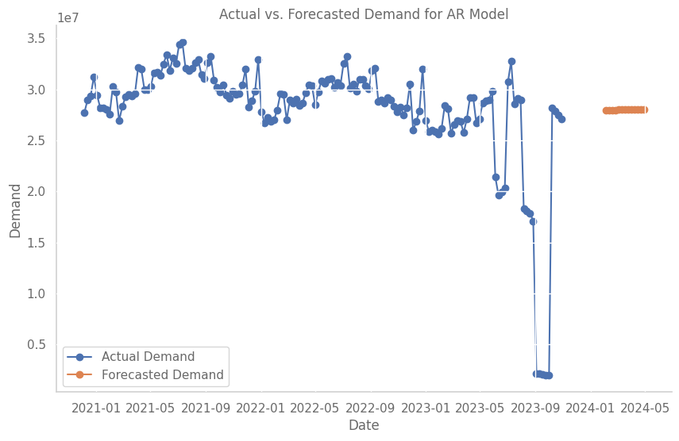

```python
# Load the dataset
data = Fact_Demand_data.copy()
data['DATE'] = pd.to_datetime(data['DATE'])
data.set_index('DATE', inplace=True)

# Extract the time series data (assuming 'UNIT_SALES' is the column to model)
time_series_data = data['UNIT_SALES']

# Check for missing values and handle them if necessary
time_series_data = time_series_data.dropna()

# Calculate weekly sales
weekly_sales = time_series_data.resample('W').sum()

# Train Autoregressive model
lag = 1  # Example lag parameter
model = AutoReg(weekly_sales, lags=lag)
results = model.fit()

# Forecast future demand
# Adjust forecast_steps to ensure it doesn't extend beyond the available data
forecast_steps = min(26, len(weekly_sales))
forecast = results.predict(start=len(weekly_sales), end=len(weekly_sales) + forecast_steps - 1, dynamic=False)

# Calculate actual values for the entire available data
actual_values = weekly_sales

# Initialize variables to store best period information
best_period_start = None
best_period_end = None
best_period_sum = -np.inf

# Iterate over each 13-week period to find the one with the highest sum of forecasted demand
for i in range(len(forecast) - 12):
    sum_demand = forecast.iloc[i:i+13].sum()
    if sum_demand > best_period_sum:
        best_period_sum = sum_demand
        best_period_start = forecast.index[i]
        best_period_end = forecast.index[i+12]

# Calculate Mean Absolute Error (MAE)
mae = mean_absolute_error(actual_values[-len(forecast):], forecast)

# Calculate Mean Squared Error (MSE)
mse = mean_squared_error(actual_values[-len(forecast):], forecast)

# Calculate Root Mean Squared Error (RMSE)
rmse = np.sqrt(mse)

# Calculate R-squared (R2)
r2 = r2_score(actual_values[-len(forecast):], forecast)

# Print the start and end dates of the period with the highest forecasted demand
print("Start date of the period with the highest forecasted demand:", best_period_start)
print("End date of the period with the highest forecasted demand:", best_period_end)

# Print actual_values to debug
print("\nActual values:")
print(actual_values)

# Print the forecasted demand for the best period
print("\nForecasted demand for the best period:")
print(forecast.loc[best_period_start:best_period_end])

# Print the evaluation metrics
print("\nEvaluation Metrics:")
print("Mean Absolute Error (MAE):", mae)
print("Mean Squared Error (MSE):", mse)
print("Root Mean Squared Error (RMSE):", rmse)
print("R-squared (R2):", r2)

# Plot the actual values and forecasted values
plt.figure(figsize=(10, 6))
plt.plot(actual_values, label='Actual Demand', marker='o')
plt.plot(forecast.loc[best_period_start:best_period_end], label='Forecasted Demand', marker='o')
plt.xlabel('Date')
plt.ylabel('Demand')
plt.title('Actual vs. Forecasted Demand for AR Model')
plt.legend()
plt.grid(True)
plt.show()
```

## 4.3 ARIMA Model</a>

```
Start date of the period with the highest forecasted demand: 2024-02-04 00:00:00
End date of the period with the highest forecasted demand: 2024-04-28 00:00:00

Actual values:
DATE
2020-12-06   27710930.00
2020-12-13   28957110.00
2020-12-20   29367885.00
2020-12-27   31242480.00
2021-01-03   29456900.00
2021-01-10   28219809.00
2021-01-17   28217722.00
2021-01-24   28019183.00
2021-01-31   27555364.00
2021-02-07   30276207.00
2021-02-14   29745555.00
2021-02-21   26932968.00
2021-02-28   28305693.00
2021-03-07   29254628.00
2021-03-14   29532751.00
2021-03-21   29325438.00
2021-03-28   29580101.00
2021-04-04   32117606.00
2021-04-11   31982057.00
2021-04-18   29995220.00
2021-04-25   29980687.00
2021-05-02   30286401.00
2021-05-09   31613857.00
2021-05-16   31687760.00
2021-05-23   31334207.00
2021-05-30   32451043.00
2021-06-06   33414078.00
2021-06-13   31847347.00
2021-06-20   33101572.00
2021-06-27   32539314.00
2021-07-04   34439759.00
2021-07-11   34618091.00
2021-07-18   32084056.00
2021-07-25   31862164.00
2021-08-01   32041537.00
```

[output cut: 125 more lines]

```
2024-03-10   28025442.78
2024-03-17   28031230.25
2024-03-24   28036091.25
2024-03-31   28040174.09
2024-04-07   28043603.35
2024-04-14   28046483.65
2024-04-21   28048902.86
2024-04-28   28050934.81
Freq: W-SUN, Name: predicted_mean, dtype: float64

Evaluation Metrics:
Mean Absolute Error (MAE): 8426295.341951074
Mean Squared Error (MSE): 155854925806801.44
Root Mean Squared Error (RMSE): 12484187.030271592
R-squared (R2): -0.5044718410005433
```

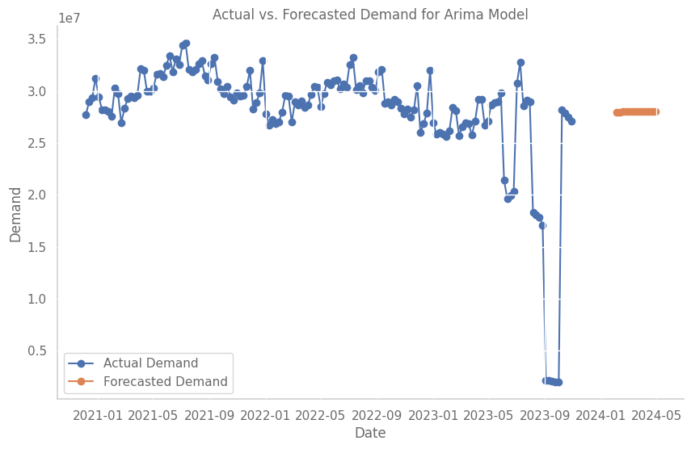

```python
from statsmodels.tsa.arima.model import ARIMA

# Load the dataset
data = Fact_Demand_data.copy()
data['DATE'] = pd.to_datetime(data['DATE'])
data.set_index('DATE', inplace=True)

# Extract the time series data (assuming 'UNIT_SALES' is the column to model)
time_series_data = data['UNIT_SALES']

# Check for missing values and handle them if necessary
time_series_data = time_series_data.dropna()

# Calculate weekly sales
weekly_sales = time_series_data.resample('W').sum()

# Train ARIMA model
order = (1, 0, 0)  # Example ARIMA order parameters (p, d, q)
model = ARIMA(weekly_sales, order=order)
results = model.fit()

# Forecast future demand
forecast_steps = min(26, len(weekly_sales))
forecast = results.predict(start=len(weekly_sales), end=len(weekly_sales) + forecast_steps - 1, dynamic=False)

# Calculate actual values for the entire available data
actual_values = weekly_sales

# Initialize variables to store best period information
best_period_start = None
best_period_end = None
best_period_sum = -np.inf

# Iterate over each 13-week period to find the one with the highest sum of forecasted demand
for i in range(len(forecast) - 12):
    sum_demand = forecast.iloc[i:i+13].sum()
    if sum_demand > best_period_sum:
        best_period_sum = sum_demand
        best_period_start = forecast.index[i]
        best_period_end = forecast.index[i+12]

# Calculate Mean Absolute Error (MAE)
mae = mean_absolute_error(actual_values[-len(forecast):], forecast)

# Calculate Mean Squared Error (MSE)
mse = mean_squared_error(actual_values[-len(forecast):], forecast)

# Calculate Root Mean Squared Error (RMSE)
rmse = np.sqrt(mse)

# Calculate R-squared (R2)
r2 = r2_score(actual_values[-len(forecast):], forecast)

# Print the start and end dates of the period with the highest forecasted demand
print("Start date of the period with the highest forecasted demand:", best_period_start)
print("End date of the period with the highest forecasted demand:", best_period_end)

# Print actual_values to debug
print("\nActual values:")
print(actual_values)

# Print the forecasted demand for the best period
print("\nForecasted demand for the best period:")
print(forecast.loc[best_period_start:best_period_end])

# Print the evaluation metrics
print("\nEvaluation Metrics:")
print("Mean Absolute Error (MAE):", mae)
print("Mean Squared Error (MSE):", mse)
print("Root Mean Squared Error (RMSE):", rmse)
print("R-squared (R2):", r2)

# Plot the actual values and forecasted values
plt.figure(figsize=(10, 6))
plt.plot(actual_values, label='Actual Demand', marker='o')
plt.plot(forecast.loc[best_period_start:best_period_end], label='Forecasted Demand', marker='o')
plt.xlabel('Date')
plt.ylabel('Demand')
plt.title('Actual vs. Forecasted Demand for Arima Model')
plt.legend()
plt.grid(True)
plt.show()
```

## 4.3.1 Question 1 with ARIMA

## Load and Explore the Dataset To Answer Question 1 from ARIMA Model</a>

```
Start date of the period with the highest forecasted demand: 2023-11-05 00:00:00
End date of the period with the highest forecasted demand: 2024-01-28 00:00:00

Actual values:
DATE
2020-12-06   6979.00
2020-12-13   5586.00
2020-12-20   4164.00
2020-12-27   3988.00
2021-01-03   3030.00
2021-01-10   2440.00
2021-01-17   2594.00
2021-01-24   2684.00
2021-01-31   2308.00
2021-02-07   2179.00
2021-02-14   2218.00
2021-02-21   2311.00
2021-02-28   2089.00
2021-03-07   2262.00
2021-03-14   2245.00
2021-03-21   2305.00
2021-03-28   2122.00
2021-04-04   2291.00
2021-04-11   2034.00
2021-04-18   2206.00
2021-04-25   2061.00
2021-05-02   1768.00
2021-05-09   2002.00
2021-05-16   1952.00
2021-05-23   2118.00
2021-05-30   2788.00
2021-06-06   4089.00
2021-06-13   4465.00
2021-06-20   5009.00
2021-06-27   5460.00
2021-07-04   6755.00
2021-07-11   5802.00
2021-07-18   4678.00
2021-07-25   4427.00
2021-08-01   3827.00
```

[output cut: 125 more lines]

```
2023-12-10   4200.90
2023-12-17   4065.77
2023-12-24   3949.26
2023-12-31   3848.80
2024-01-07   3762.18
2024-01-14   3687.50
2024-01-21   3623.11
2024-01-28   3567.59
Freq: W-SUN, Name: predicted_mean, dtype: float64

Evaluation Metrics:
Mean Absolute Error (MAE): 2216.0015106305054
Mean Squared Error (MSE): 5907513.114831001
Root Mean Squared Error (RMSE): 2430.537618476826
R-squared (R2): -0.07394545295081123
```

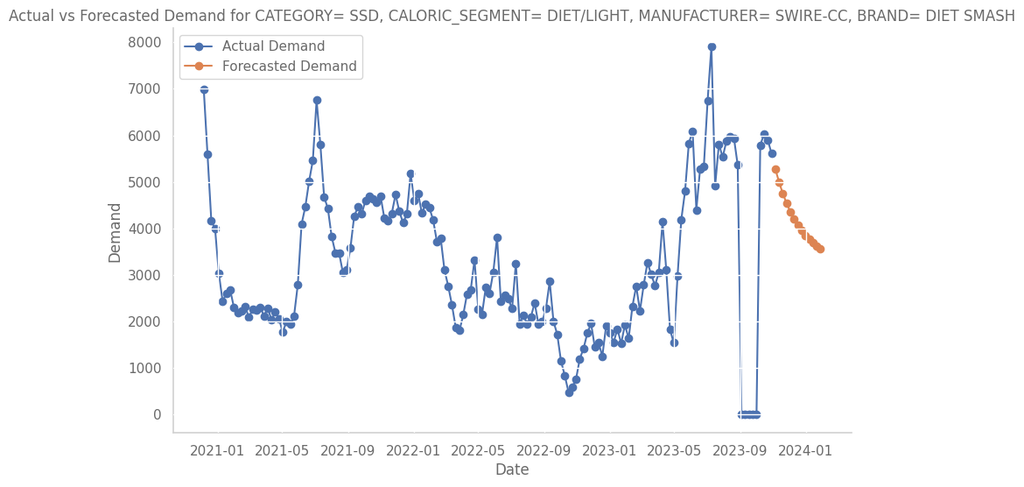

```python
from statsmodels.tsa.arima.model import ARIMA

# Load the dataset
data = Fact_Demand_data.copy()
data['DATE'] = pd.to_datetime(data['DATE'])
data.set_index('DATE', inplace=True)


# Apply filters to the dataset
category_data = data[(data['CATEGORY'] == 'SSD') & (data['CALORIC_SEGMENT'] == 'DIET/LIGHT') & (data['MANUFACTURER'] == 'SWIRE-CC') & (data['BRAND'] == 'DIET SMASH')]

# Extract the time series data (assuming 'UNIT_SALES' is the column to model)
time_series_data = category_data['UNIT_SALES']

# Check for missing values and handle them if necessary
time_series_data = time_series_data.dropna()

# Calculate weekly sales
weekly_sales = time_series_data.resample('W').sum()

# Train ARIMA model
order = (1, 0, 0)  # Example ARIMA order (p, d, q)
model = ARIMA(weekly_sales, order=order)
results = model.fit()

# Forecast future demand
# Adjust forecast_steps to ensure it doesn't extend beyond the available data
forecast_steps = min(26, len(weekly_sales))
forecast = results.predict(start=len(weekly_sales), end=len(weekly_sales) + forecast_steps - 1, dynamic=False)

# Calculate actual values for the entire available data
actual_values = weekly_sales

# Initialize variables to store best period information
best_period_start = None
best_period_end = None
best_period_sum = -np.inf

# Iterate over each 13-week period to find the one with the highest sum of forecasted demand
for i in range(len(forecast) - 12):
    sum_demand = forecast.iloc[i:i+13].sum()
    if sum_demand > best_period_sum:
        best_period_sum = sum_demand
        best_period_start = forecast.index[i]
        best_period_end = forecast.index[i+12]

# Calculate Mean Absolute Error (MAE)
mae = mean_absolute_error(actual_values[-len(forecast):], forecast)

# Calculate Mean Squared Error (MSE)
mse = mean_squared_error(actual_values[-len(forecast):], forecast)

# Calculate Root Mean Squared Error (RMSE)
rmse = np.sqrt(mse)

# Calculate R-squared (R2)
r2 = r2_score(actual_values[-len(forecast):], forecast)

# Print the start and end dates of the period with the highest forecasted demand
print("Start date of the period with the highest forecasted demand:", best_period_start)
print("End date of the period with the highest forecasted demand:", best_period_end)

# Print actual_values to debug
print("\nActual values:")
print(actual_values)

# Print the forecasted demand for the best period
print("\nForecasted demand for the best period:")
print(forecast.loc[best_period_start:best_period_end])

# Print the evaluation metrics
print("\nEvaluation Metrics:")
print("Mean Absolute Error (MAE):", mae)
print("Mean Squared Error (MSE):", mse)
print("Root Mean Squared Error (RMSE):", rmse)
print("R-squared (R2):", r2)

# Plot the actual values and forecasted values
plt.figure(figsize=(10, 6))
plt.plot(actual_values, label='Actual Demand', marker='o')
plt.plot(forecast.loc[best_period_start:best_period_end], label='Forecasted Demand', marker='o')
plt.xlabel('Date')
plt.ylabel('Demand')
plt.title('Actual vs Forecasted Demand for CATEGORY= SSD, CALORIC_SEGMENT= DIET/LIGHT, MANUFACTURER= SWIRE-CC, BRAND= DIET SMASH')
plt.legend()
plt.grid(True)
plt.show()
```

## 4.3.2 Question 3 with ARIMA

## Load and Explore the Dataset To Answer Question 3 from ARIMA Model</a>

```
Start date of the period with the highest forecasted demand: 2024-02-04 00:00:00
End date of the period with the highest forecasted demand: 2024-04-28 00:00:00

Actual values:
DATE
2020-12-06   4761.00
2020-12-13   4598.00
2020-12-20   4759.00
2020-12-27   4203.00
2021-01-03   4546.00
2021-01-10   4593.00
2021-01-17   4779.00
2021-01-24   4615.00
2021-01-31   4736.00
2021-02-07   4684.00
2021-02-14   4547.00
2021-02-21   4578.00
2021-02-28   4550.00
2021-03-07   4614.00
2021-03-14   4597.00
2021-03-21   4584.00
2021-03-28   3935.00
2021-04-04   3961.00
2021-04-11   3843.00
2021-04-18   3912.00
2021-04-25   4024.00
2021-05-02   3858.00
2021-05-09   4272.00
2021-05-16   4286.00
2021-05-23   4112.00
2021-05-30   3859.00
2021-06-06   3805.00
2021-06-13   3601.00
2021-06-20   3908.00
2021-06-27   3770.00
2021-07-04   3500.00
2021-07-11   3985.00
2021-07-18   4051.00
2021-07-25   3687.00
2021-08-01   4300.00
```

[output cut: 125 more lines]

```
2024-03-10   2426.93
2024-03-17   2449.18
2024-03-24   2470.42
2024-03-31   2490.70
2024-04-07   2510.05
2024-04-14   2528.52
2024-04-21   2546.14
2024-04-28   2562.97
Freq: W-SUN, Name: predicted_mean, dtype: float64

Evaluation Metrics:
Mean Absolute Error (MAE): 1323.4176648975913
Mean Squared Error (MSE): 2737502.5816264497
Root Mean Squared Error (RMSE): 1654.5399909420291
R-squared (R2): -2.02577595069283
```

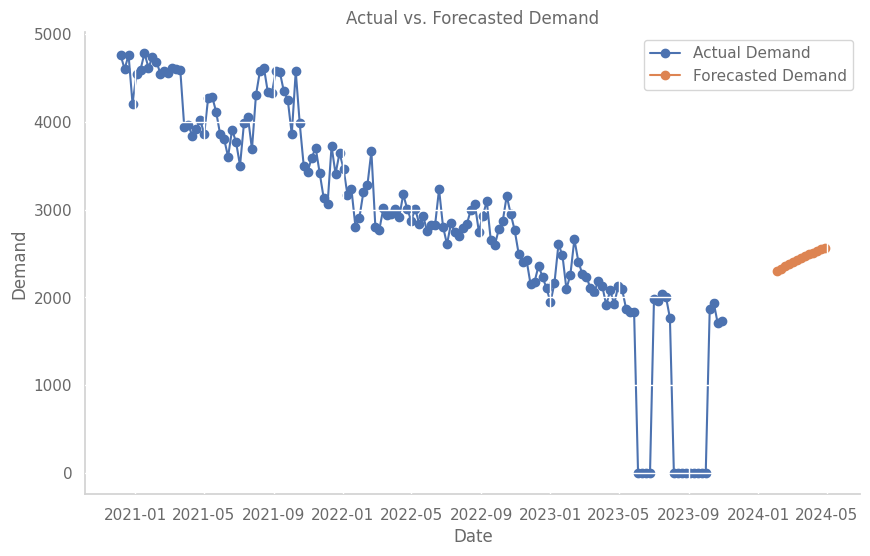

```python
from statsmodels.tsa.arima.model import ARIMA


# Load the dataset
data = Fact_Demand_data.copy()
data['DATE'] = pd.to_datetime(data['DATE'])
data.set_index('DATE', inplace=True)

# Apply filters to the dataset
category_data = data[(data['CATEGORY'] == 'ENERGY') & (data['CALORIC_SEGMENT'] == 'DIET/LIGHT') & (data['MANUFACTURER'] == 'SWIRE-CC') & (data['BRAND'] == 'VENOMOUS BLAST')]

# Extract the time series data (assuming 'UNIT_SALES' is the column to model)
time_series_data = category_data['UNIT_SALES']

# Check for missing values and handle them if necessary
time_series_data = time_series_data.dropna()

# Calculate weekly sales
weekly_sales = time_series_data.resample('W').sum()

# Train ARIMA model
order = (1, 0, 0)  # Example ARIMA order (p, d, q)
model = ARIMA(weekly_sales, order=order)
results = model.fit()

# Forecast future demand
# Adjust forecast_steps to ensure it doesn't extend beyond the available data
forecast_steps = min(26, len(weekly_sales))
forecast = results.predict(start=len(weekly_sales), end=len(weekly_sales) + forecast_steps - 1, dynamic=False)

# Calculate actual values for the entire available data
actual_values = weekly_sales

# Initialize variables to store best period information
best_period_start = None
best_period_end = None
best_period_sum = -np.inf

# Iterate over each 13-week period to find the one with the highest sum of forecasted demand
for i in range(len(forecast) - 12):
    sum_demand = forecast.iloc[i:i+13].sum()
    if sum_demand > best_period_sum:
        best_period_sum = sum_demand
        best_period_start = forecast.index[i]
        best_period_end = forecast.index[i+12]

# Calculate Mean Absolute Error (MAE)
mae = mean_absolute_error(actual_values[-len(forecast):], forecast)

# Calculate Mean Squared Error (MSE)
mse = mean_squared_error(actual_values[-len(forecast):], forecast)

# Calculate Root Mean Squared Error (RMSE)
rmse = np.sqrt(mse)

# Calculate R-squared (R2)
r2 = r2_score(actual_values[-len(forecast):], forecast)

# Print the start and end dates of the period with the highest forecasted demand
print("Start date of the period with the highest forecasted demand:", best_period_start)
print("End date of the period with the highest forecasted demand:", best_period_end)

# Print actual_values to debug
print("\nActual values:")
print(actual_values)

# Print the forecasted demand for the best period
print("\nForecasted demand for the best period:")
print(forecast.loc[best_period_start:best_period_end])

# Print the evaluation metrics
print("\nEvaluation Metrics:")
print("Mean Absolute Error (MAE):", mae)
print("Mean Squared Error (MSE):", mse)
print("Root Mean Squared Error (RMSE):", rmse)
print("R-squared (R2):", r2)

# Plot the actual values and forecasted values
plt.figure(figsize=(10, 6))
plt.plot(actual_values, label='Actual Demand', marker='o')
plt.plot(forecast.loc[best_period_start:best_period_end], label='Forecasted Demand', marker='o')
plt.xlabel('Date')
plt.ylabel('Demand')
plt.title('Actual vs. Forecasted Demand')
plt.legend()
plt.grid(True)
plt.show()
```

However, notable discrepancies exist between forecasted and actual sales data, as evidenced by high error metrics MAE and RMSE and a negative R-squared value. This underscores the necessity for improvements in the forecasting model to better capture market dynamics.

## 4.4. Prophet Model

## 4.4.1. Holiday Data

First getting reading the holiday data for the US so that the pattern for the holidays can be understood. The lower window is for -2 so that it can consider 2 dys before the holiday and 1 for upper window, so that it can consider one day after the holiday

```python
#adding holiday data

holiday = pd.DataFrame([])

for date_, name in sorted(holidays.US(years=[2020,2021,2022,2023,2024]).items()):
    holiday = pd.concat([holiday, pd.DataFrame({'ds': date_, 'holiday': "US-Holidays", 'lower_window': -2, 'upper_window': 1}, index=[0])], ignore_index=True)

holiday['ds'] = pd.to_datetime(holiday['ds'], format='%Y-%m-%d', errors='ignore')
holiday.head()
```

|  | ds | holiday | lower_window | upper_window |
| --- | --- | --- | --- | --- |
| 0 | 2020-01-01 | US-Holidays | -2 | 1 |
| 1 | 2020-01-20 | US-Holidays | -2 | 1 |
| 2 | 2020-02-17 | US-Holidays | -2 | 1 |
| 3 | 2020-05-25 | US-Holidays | -2 | 1 |
| 4 | 2020-07-03 | US-Holidays | -2 | 1 |

```python
#converting the column names to lower characters and replacing spaces by underscore
fact_demand_state_data.columns = fact_demand_state_data.columns.str.replace(' ', '_').str.lower()

#converting the date format to year-month-date
fact_demand_state_data['date'] = pd.to_datetime(fact_demand_state_data['date'], format= "%Y/%m/%d")
```

```python
# Finding the minimum and maximum dates in the data
min(fact_demand_state_data['date']), max(fact_demand_state_data['date'])
```

```
(Timestamp('2020-12-05 00:00:00'), Timestamp('2023-10-28 00:00:00'))
```

```python
fact_demand_state_data.head()
```

|  | date | market_key | caloric_segment | category | unit_sales | dollar_sales | manufacturer | brand | package | item | states |
| --- | --- | --- | --- | --- | --- | --- | --- | --- | --- | --- | --- |
| 0 | 2020-12-05 | 1 | REGULAR | ENERGY | 3.00 | 23.88 | JORDYS | LIQUORICE | ALL OTHER ONES | AAE LIQUORICE XTREME DIETARY HEALTH SUPPLEMENT... | ID |
| 1 | 2020-12-05 | 1 | REGULAR | ENERGY | 1.00 | 7.96 | JORDYS | LIQUORICE | ALL OTHER ONES | AAE LIQUORICE XTREME REVITALIZING BOOST LIQUID... | ID |
| 2 | 2020-12-05 | 1 | DIET/LIGHT | ENERGY | 9.00 | 23.78 | JORDYS | LIQUORICE | ALL OTHER ONES | AAE LIQUORICE XTREME REVITALIZING BOOST LIQUID... | ID |
| 3 | 2020-12-05 | 1 | DIET/LIGHT | SPARKLING WATER | 114.00 | 375.09 | JOLLYS | BUBBLE JOY | 12SMALL 8ONE CUP | BUBBLE JOY SPARKLING WATER CASAVA BUBBLE JOY ... | ID |
| 4 | 2020-12-05 | 1 | DIET/LIGHT | SPARKLING WATER | 178.00 | 588.82 | JOLLYS | BUBBLE JOY | 12SMALL 8ONE CUP | BUBBLE JOY SPARKLING WATER DURIAN BUBBLE JOY ... | ID |

## 4.4.2. Question 1

Writing the segments for the Qestion 1.  
a. caloric Segment - Diet  
b. Market Category - SSD  
c. Manufacturer - Swire-CC  
d. Brand - Diet Smash  
e. Package Type - 11Small4One  
f. Flavor - Plum

Now, checking which lines in the data will yield to the most closest for our forecast.

```python
q1_f1 = fact_demand_state_data['caloric_segment'] == 'DIET/LIGHT'
q1_f2 = fact_demand_state_data['category'] == 'SSD'
q1_f3 = fact_demand_state_data['brand'] == 'DIET SMASH'
q1_f4 = fact_demand_state_data['item'].str.lower().str.contains('plum')

filter_condition_q1 = (( q1_f1 & q1_f2 & q1_f3 ) | ( q1_f4 & q1_f2 & q1_f1 ))

q1_df = fact_demand_state_data[filter_condition_q1]

q1_df.head()
```

|  | date | market_key | caloric_segment | category | unit_sales | dollar_sales | manufacturer | brand | package | item | states |
| --- | --- | --- | --- | --- | --- | --- | --- | --- | --- | --- | --- |
| 2859 | 2020-12-05 | 23 | DIET/LIGHT | SSD | 72.00 | 115.29 | SWIRE-CC | DIET SMASH | 2L MULTI JUG | DIET SMASH GENTLE DRINK SUNSET DIET JUG 67.6 ... | OR |
| 6381 | 2020-12-05 | 50 | DIET/LIGHT | SSD | 46.00 | 74.17 | SWIRE-CC | DIET SMASH | 2L MULTI JUG | DIET SMASH GENTLE DRINK SUNSET DIET JUG 67.6 ... | WA/ID |
| 7172 | 2020-12-05 | 56 | DIET/LIGHT | SSD | 3.00 | 13.98 | SWIRE-CC | DIET SMASH | 12SMALL 12ONE CUP | DIET SMASH GENTLE DRINK SUNSET DIET CUP 12 LI... | OR/WA |
| 7173 | 2020-12-05 | 56 | DIET/LIGHT | SSD | 25.00 | 33.45 | SWIRE-CC | DIET SMASH | 2L MULTI JUG | DIET SMASH GENTLE DRINK SUNSET DIET JUG 67.6 ... | OR/WA |
| 9500 | 2020-12-05 | 61 | DIET/LIGHT | SSD | 33.00 | 53.11 | SWIRE-CC | DIET SMASH | 2L MULTI JUG | DIET SMASH GENTLE DRINK SUNSET DIET JUG 67.6 ... | OR |

```python
q1_df.shape
```

```
(17484, 11)
```

```python
min(q1_df['date']), max(q1_df['date'])
```

```
(Timestamp('2020-12-05 00:00:00'), Timestamp('2023-10-28 00:00:00'))
```

```python
q1_agg_df = q1_df.groupby(['date']).agg({'unit_sales': 'sum', 'item': 'nunique'}).reset_index().sort_values(['date'])
q1_agg_df['unit_sales'] = q1_agg_df['unit_sales'] / q1_agg_df['item']
q1_agg_df.drop(columns=['item'],inplace=True)
```

```python
#q1_agg_df = q1_df.groupby(['date']).agg({'unit_sales':'sum'}).reset_index().sort_values(['date'])
```

```python
q1_agg_df.head()
```

|  | date | unit_sales |
| --- | --- | --- |
| 0 | 2020-12-05 | 3489.50 |
| 1 | 2020-12-12 | 2793.00 |
| 2 | 2020-12-19 | 2082.00 |
| 3 | 2020-12-26 | 1994.00 |
| 4 | 2021-01-02 | 1515.00 |

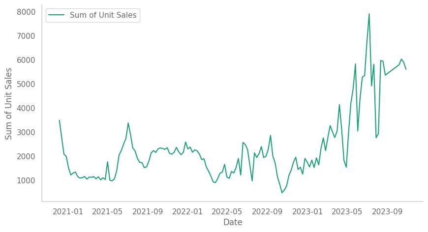

```python
# @title date vs sum of unit_sales

from matplotlib import pyplot as plt
import seaborn as sns
def _plot_series(series, series_name, series_index=0):
  palette = list(sns.palettes.mpl_palette('Dark2'))
    # Aggregate sum of unit sales by date
  summed = series.groupby('date')['unit_sales'].sum().reset_index()

  xs = summed['date']
  ys = summed['unit_sales']
  plt.plot(xs, ys, label=series_name, color=palette[series_index % len(palette)])

# Example usage:
fig, ax = plt.subplots(figsize=(10, 5.2))
df_sorted = q1_agg_df.sort_values('date', ascending=True)
_plot_series(df_sorted, 'Sum of Unit Sales')
sns.despine(fig=fig, ax=ax)
plt.xlabel('Date')
plt.ylabel('Sum of Unit Sales')
plt.legend()
plt.show()
```

```python
missing_data(q1_agg_df).head()
```

|  | Total | Percent | Types |
| --- | --- | --- | --- |
| date | 0 | 0.00 | datetime64[ns] |
| unit_sales | 0 | 0.00 | float64 |

```python
#total_sales_df1 = q1_agg_df.dropna()
```

```python
q1_agg_df.shape
```

```
(147, 2)
```

```python
Q1_sales_data_df = q1_agg_df[q1_agg_df.date<='2023-06-05']
Q1_test_set_df = q1_agg_df[q1_agg_df.date>='2023-06-05']
```

```python
Q1_sales_data_df.shape
```

```
(131, 2)
```

```python
Q1_test_set_df.shape
```

```
(16, 2)
```

```python
changepoint_prior_scale_range = np.linspace(0.001, 0.5, num=5).tolist()
print(changepoint_prior_scale_range)
```

```
[0.001, 0.12575, 0.2505, 0.37525, 0.5]
```

```python
seasonality_prior_scale_range = np.linspace(0.01, 10, num=5).tolist()
```

```python
start_time = time.time()

#category_df = Q1_sales_data_df[['date','unit_sales']]

def best_params(category_df):
    category_df.rename(columns={'date': 'ds', 'unit_sales': 'y'}, inplace=True)
    category_df[["y"]] = category_df[["y"]].apply(pd.to_numeric)
    category_df["ds"] = pd.to_datetime(category_df["ds"])

    param_grid = {
        "changepoint_prior_scale": changepoint_prior_scale_range,
        "seasonality_prior_scale": seasonality_prior_scale_range }

    # Generate all combinations of parameters
    all_params = [dict(zip(param_grid.keys(), v)) for v in itertools.product(*param_grid.values())]
    mapes = []

    # Use cross validation to evaluate all parameters
    for params in all_params:
         m = Prophet(**params).fit(category_df)  # Fit model with given params
         df_cv = cross_validation(m, initial="365 days", period="30 days", horizon = "30 days") #took parallel out
         df_p = performance_metrics(df_cv, rolling_window=1)
         mapes.append(df_p["mape"].values[0])

    # Find the best parameters
    tuning_results = pd.DataFrame(all_params)
    tuning_results["mape"] = mapes

    params_dict = dict(tuning_results.sort_values("mape").reset_index(drop=True).iloc[0])

    return params_dict

params1_dict = best_params(Q1_sales_data_df)

print("--- %s seconds ---" % (time.time() - start_time))
```

[output not shown]

[output not shown]

[output cut: 216 more lines]

[output not shown]

[output not shown]

[output cut: 216 more lines]

[output not shown]

[output not shown]

[output cut: 216 more lines]

[output not shown]

[output not shown]

[output cut: 216 more lines]

[output not shown]

[output not shown]

[output cut: 204 more lines]

[output not shown]

[output not shown]

[output cut: 120 more lines]

[output not shown]

[output not shown]

[output cut: 120 more lines]

[output not shown]

[output not shown]

[output cut: 120 more lines]

[output not shown]

[output not shown]

[output cut: 120 more lines]

[output not shown]

[output not shown]

[output cut: 120 more lines]

[output not shown]

[output not shown]

[output cut: 120 more lines]

[output not shown]

[output not shown]

[output cut: 120 more lines]

[output not shown]

[output not shown]

[output cut: 120 more lines]

[output not shown]

[output not shown]

[output cut: 120 more lines]

[output not shown]

[output not shown]

[output cut: 120 more lines]

[output not shown]

[output not shown]

[output cut: 120 more lines]

[output not shown]

[output not shown]

[output cut: 120 more lines]

[output not shown]

[output not shown]

[output cut: 120 more lines]

[output not shown]

[output not shown]

[output cut: 120 more lines]

[output not shown]

[output not shown]

[output cut: 120 more lines]

[output not shown]

[output not shown]

[output cut: 120 more lines]

[output not shown]

[output not shown]

[output cut: 120 more lines]

[output not shown]

[output not shown]

[output cut: 120 more lines]

[output not shown]

[output not shown]

[output cut: 120 more lines]

[output not shown]

[output not shown]

[output cut: 107 more lines]

[output not shown]

```
--- 238.347900390625 seconds ---
```

```python
params1_dict
```

```
{'changepoint_prior_scale': 0.12575,
 'seasonality_prior_scale': 0.01,
 'mape': 0.406511161078941}
```

```python
prediction_days = 16
forecast_start_date = max(Q1_sales_data_df.ds) - timedelta(prediction_days)
```

```python
#PROPHET MODEL

#model
m = Prophet(changepoint_prior_scale=params1_dict['changepoint_prior_scale'],
            seasonality_prior_scale=params1_dict['seasonality_prior_scale'],
            holidays=holiday)

m.fit(Q1_sales_data_df)

future = m.make_future_dataframe(periods=52, freq='W-SAT')
fcst_prophet_train = m.predict(future)

filter = fcst_prophet_train['ds']>=forecast_start_date
predicted_df = fcst_prophet_train[filter][['ds','yhat']]
predicted_df = predicted_df.merge(Q1_sales_data_df)

print(mape(predicted_df['y'],predicted_df['yhat']))
```

[output not shown]

```
26.353485952312354
```

```python
print(forecast_start_date)
```

```
2023-05-18 00:00:00
```

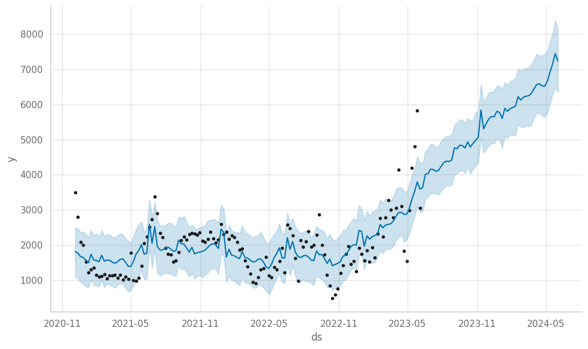

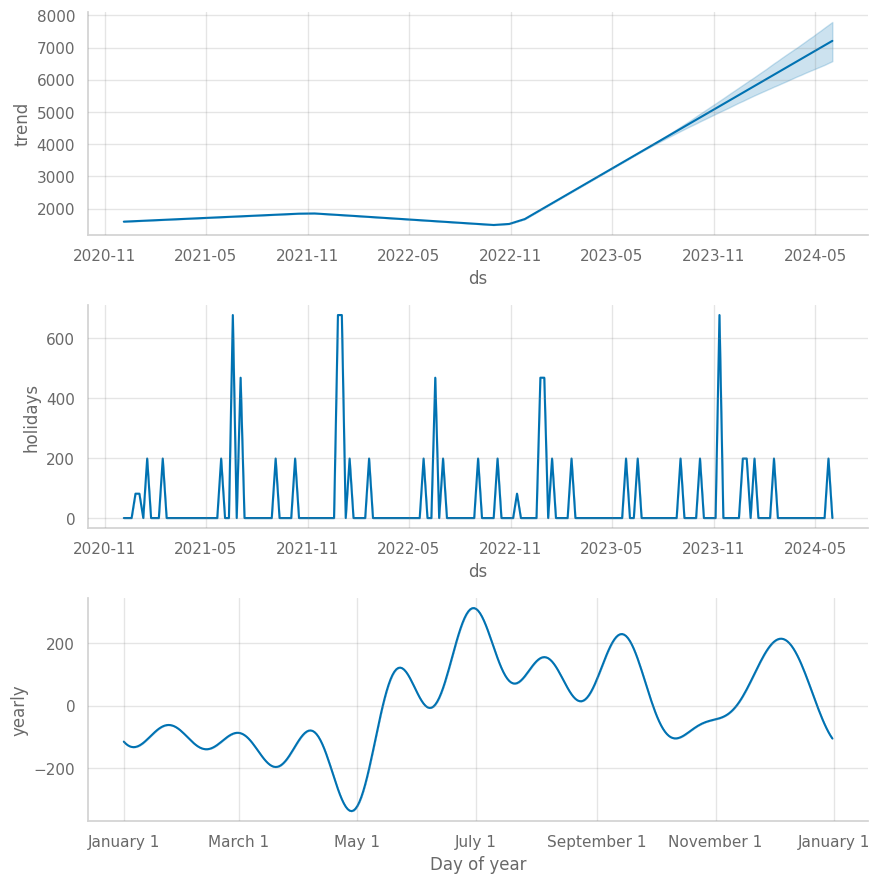

```python
fig1 = m.plot(fcst_prophet_train)
fig2 = m.plot_components(fcst_prophet_train)

forecasted_df = fcst_prophet_train[fcst_prophet_train['ds']>=forecast_start_date]
```

```python
forecast_start_date = '2023-06-05'

future = m.make_future_dataframe(periods=16, freq='W-SAT')
fcst_prophet_train = m.predict(future)

filter = fcst_prophet_train['ds']>=forecast_start_date
predicted_df = fcst_prophet_train[filter][['ds','yhat']]



# Calculate Mean Absolute Percentage Error (MAPE)
mape_v = mape(Q1_test_set_df['unit_sales'],predicted_df['yhat'])


# Calculate Mean Absolute Error (MAE)
mae = mean_absolute_error(Q1_test_set_df['unit_sales'],predicted_df['yhat'])

# Calculate Mean Squared Error (MSE)
mse = mean_squared_error(Q1_test_set_df['unit_sales'],predicted_df['yhat'])

# Calculate Root Mean Squared Error (RMSE)
rmse = np.sqrt(mse)

# Calculate R-squared (R2)
r2 = r2_score(Q1_test_set_df['unit_sales'],predicted_df['yhat'])

print(f"-----------------------Features---------------------------")

print(f'Mean Absolute Error- MAE: {mae}')
print(f'Mean Squared Error- MSE: {mse}')
print(f'Root Mean Square Error- RMSE: {rmse}')
print(f'R2:R-squared{r2}')
print(f'Mean Absolute Percentage Error- MAPE: {mape_v}')
```

```
-----------------------Features---------------------------
Mean Absolute Error- MAE: 1457.7534713440446
Mean Squared Error- MSE: 2669798.2981711663
Root Mean Square Error- RMSE: 1633.9517429138373
R2:R-squared-0.7819012076829785
Mean Absolute Percentage Error- MAPE: 27.5135405614711
```

```python
forecast_start_date = '2023-12-30'

future = m.make_future_dataframe(periods=85, freq='W-SAT')
fcst_prophet_train = m.predict(future)

filter = fcst_prophet_train['ds']>=forecast_start_date
predicted_13_df = fcst_prophet_train[filter][['ds','yhat']]

predicted_13_df.tail()
```

|  | ds | yhat |
| --- | --- | --- |
| 211 | 2024-12-21 | 9268.88 |
| 212 | 2024-12-28 | 9231.06 |
| 213 | 2025-01-04 | 9246.59 |
| 214 | 2025-01-11 | 9327.43 |
| 215 | 2025-01-18 | 9437.88 |

```python
# Initialize variables to store the maximum sum and its corresponding index
max_sum = float('-inf')
max_index = -1

# Calculate the sum of the first 13 values as the initial maximum sum
current_sum = predicted_13_df['yhat'].iloc[:13].sum()

# Iterate through the DataFrame to find the maximum sum
for i in range(len(predicted_13_df) - 13):
    if current_sum > max_sum:
        max_sum = current_sum
        max_index = i

    # Update the sum for the next window
    current_sum = current_sum - predicted_13_df['yhat'].iloc[i] + predicted_13_df['yhat'].iloc[i + 13]

# Print the maximum sum and its corresponding index
print("Maximum sum:", max_sum)
print("Index of the first element in the set:", max_index)

print("Date of the start of the 13th year:", predicted_13_df['ds'].iloc[max_index])

print(predicted_13_df.iloc[max_index:max_index+13])
```

```
Maximum sum: 117786.38842817597
Index of the first element in the set: 42
Date of the start of the 13th year: 2024-10-19 00:00:00
            ds    yhat
202 2024-10-19 8526.12
203 2024-10-26 8622.29
204 2024-11-02 8704.72
205 2024-11-09 8997.61
206 2024-11-16 8930.24
207 2024-11-23 9087.35
208 2024-11-30 9226.93
209 2024-12-07 9305.92
210 2024-12-14 9311.25
211 2024-12-21 9268.88
212 2024-12-28 9231.06
213 2025-01-04 9246.59
214 2025-01-11 9327.43
```